# model_presentation

# 1 Load packages & data

```r
Sys.setenv(TZ="Europe/Paris") # Strange warning on my R versions - should update

library(lightgbm)
library(data.table)
library(RcppRoll)
library(dtplyr)
library(stringr)
library(tidyverse)
library(lubridate)

source("src/utilities.R")

SAMPLING_SIZE = 20 # Size of sampling - see function generate_target(...)
```

```r
# Read data ---------------------------------------------------------------
print("Read data")
```

```
## [1] "Read data"
```

```r
holidays = read_csv("./data/holidays.csv") %>% select(-1)
metadata = read_csv("./data/metadata.csv")
submission_format = read_csv("./data/submission_format.csv")
train = read_csv("./data/train.csv")
weather = read_csv("./data/weather.csv") %>% select(-1)

test = submission_format %>%
  mutate(Value = NA)
```

For the sake of simplicity in this notebook, only some buildings are going to be trained.

```r
# Sampling -----------------------------------------------------
set.seed(7)
sample_SiteId = train$SiteId %>% sample(10)

holidays = holidays %>%
  filter(SiteId %in% sample_SiteId)

metadata = metadata %>%
  filter(SiteId %in% sample_SiteId)

submission_format = submission_format %>%
  filter(SiteId %in% sample_SiteId)

train = train %>%
  filter(SiteId %in% sample_SiteId)

weather = weather %>%
  filter(SiteId %in% sample_SiteId)

test = test %>%
  filter(SiteId %in% sample_SiteId)
```

We create a dummy series which we will use later on.

```r
# Generate dummy series
dummy_series = tibble(Timestamp = seq.Date(from = ymd("2016-01-01"), to = ymd("2017-12-31"), by = "days"))
dummy_series = dummy_series %>%
  mutate(SiteId = 999L) %>%
  mutate(Value = ifelse(year(Timestamp) == 2017, 1000, 500))

dummy_series = dummy_series %>%
  mutate(Timestamp = as.POSIXct(Timestamp))

dummy_series = dummy_series %>%
  mutate(ForecastId = ifelse(Timestamp < ymd("20170101") + ddays(60), 9999, 10000))

train = dummy_series %>%
  filter(!((Timestamp >= ymd("20170101") & Timestamp < ymd("20170101") + ddays(60)) |
             (Timestamp >= ymd("20171231") - ddays(60)))) %>%
  bind_rows(train, .)

test = dummy_series %>%
  filter(((Timestamp >= ymd("20170101") & Timestamp < ymd("20170101") + ddays(60)) |
            (Timestamp >= ymd("20171231") - ddays(60)))) %>%
  select(-Value) %>%
  bind_rows(test, .)

submission_format = dummy_series %>%
  filter(((Timestamp >= ymd("20170101") & Timestamp < ymd("20170101") + ddays(60)) |
            (Timestamp >= ymd("20171231") - ddays(60)))) %>%
  mutate(Value = 0) %>%
  bind_rows(submission_format, .)
```

# 2 Data cleaning

## 2.1 Weather

Bellow is a sample of weather data.

Some SiteId don’t have weather informations. Some have multiples ones. Timestamp doesn’t have the value or frequency than training data.

```r
weather %>% sample_n(10)
```

| Timestamp | Temperature | Distance | SiteId |
| --- | --- | --- | --- |
| 2017-08-26 05:50:00 | 17.0 | 16.135872 | 25 |
| 2016-12-04 23:55:00 | 13.0 | 27.298852 | 49 |
| 2013-05-29 11:00:00 | 8.1 | 26.268435 | 302 |
| 2016-02-06 06:20:00 | 9.0 | 16.135872 | 25 |
| 2014-09-09 06:20:00 | 20.0 | 19.909826 | 123 |
| 2015-10-29 00:50:00 | 10.0 | 16.135872 | 25 |
| 2015-03-17 23:50:00 | 8.0 | 5.520573 | 149 |
| 2014-03-04 19:20:00 | 6.0 | 16.135872 | 25 |
| 2017-09-19 06:00:00 | 10.0 | 26.268435 | 302 |
| 2017-10-27 21:50:00 | 18.0 | 10.625780 | 84 |

There might have multiple values of the same (SiteId, Timestamp) because weather is mesured from different stations. We want to deduplicate these. In order to do so, we keep the value with the closest Distance.

Disclaimer : This part might be refactored in order to keep temperature from only one station and not different ones. But Ia tradeoff between the closest station and the station with the more Timestamp should be choosen.

```r
# Feature engineering -----------------------------------------------------

# Dedup weather (SiteId, Timestamp) ---------------------------------------
print("Dedup weather (SiteId, Timestamp)")
```

```
## [1] "Dedup weather (SiteId, Timestamp)"
```

```r
# Dedup (SiteId, Timestamp) : Multiple weather station by SiteId, therefore we'll only keep the closest one
weather = weather %>%
  group_by(SiteId, Timestamp) %>%
  arrange(Distance) %>%
  slice(1) %>%
  ungroup()

weather = weather %>%
  rename(Timestamp_weather = Timestamp) %>%
  mutate(Timestamp_lead = Timestamp_weather)

weather = weather %>% as.data.table()
```

## 2.2 Remove outliers

There are some outliers in the dataset. We remove points which value are ten times above the mean. This is a really basic rules, which should probably be improved.

```r
train %>% sample_n(10)
```

| obs_id | SiteId | Timestamp | ForecastId | Value |
| --- | --- | --- | --- | --- |
| 5327464 | 261 | 2015-03-12 19:45:00 | 5517 | 30605.5094 |
| 1585147 | 84 | 2015-11-18 07:40:00 | 1664 | 3819.6126 |
| 2084821 | 302 | 2017-07-28 00:30:00 | 6959 | 27747.8444 |
| 7215666 | 302 | 2014-12-31 07:30:00 | 6881 | 46911.7345 |
| 1585160 | 302 | 2017-05-06 04:00:00 | 6952 | 27747.8444 |
| 814419 | 14 | 2016-07-06 22:45:00 | 474 | 35986.5364 |
| 6230106 | 261 | 2014-11-03 12:45:00 | 5506 | 36142.5453 |
| 1194887 | 149 | 2016-06-09 22:15:00 | 3188 | 3729.4281 |
| 3832244 | 302 | 2016-11-04 00:45:00 | 6937 | 27747.8444 |
| 718670 | 123 | 2014-01-20 11:15:00 | 2709 | 120.8694 |

```r
# Clean outliers in train data --------------------------------------------
print("Clean outliers in train data")
```

```
## [1] "Clean outliers in train data"
```

```r
k = 10
train = train %>%
  group_by(ForecastId) %>%
  mutate(value_mean = mean(Value, na.rm = T)) %>%
  ungroup() %>%
  mutate(Value = if_else((Value / value_mean) > k, # | (Value / value_roll_median) < 1/k,
                         true = as.double(NA), false = Value)) %>%
  select(-value_mean)
rm(k)
```

# 3 Feature engineering

## 3.1 forecast_info - information about ForecastId

SiteId have multiple ForecastId. We want to know what are the timestep between each values and also the number of observation between day and hour. This informations will be used later on.

There are multiple timestep values

forecast_info is created from test. Some ForecastId are a bit shorter, in order to not biased our training set we’ll create further one, we correct the size of the ForecastId.

Based on (ForecastId)

```r
# forecast_info - information about ForecastId ----------------------------
print("forecast_info - information about ForecastId")
```

```
## [1] "forecast_info - information about ForecastId"
```

```r
forecast_info = test %>%
  group_by(ForecastId) %>%
  mutate(timestep_minutes = (Timestamp - lag(Timestamp)) / dseconds(60)) %>%
  summarise(size = n(), timestep_minutes = max(timestep_minutes, na.rm = T)) %>%
  ungroup()

forecast_info = forecast_info %>%
  mutate(step_day = 1440 / timestep_minutes,
         step_hour = 60 / timestep_minutes) %>%
  mutate(step_hour = ifelse(step_hour < 1, NA, step_hour) %>% as.integer())

forecast_info_tmp = forecast_info %>%
  group_by(timestep_minutes) %>%
  arrange(size) %>%
  mutate(size_adjusted = last(size)) %>%
  ungroup() %>%
  arrange(ForecastId)
```

```r
forecast_info_tmp %>% sample_n(5) %>% head()
```

| ForecastId | size | timestep_minutes | step_day | step_hour | size_adjusted |
| --- | --- | --- | --- | --- | --- |
| 5553 | 192 | 15 | 96 | 4 | 192 |
| 1200 | 192 | 15 | 96 | 4 | 192 |
| 810 | 192 | 15 | 96 | 4 | 192 |
| 6961 | 192 | 15 | 96 | 4 | 192 |
| 2723 | 192 | 15 | 96 | 4 | 192 |

```r
forecast_info_tmp %>%
  count(size, step_day, step_hour, timestep_minutes)
```

| size | step_day | step_hour | timestep_minutes | n |
| --- | --- | --- | --- | --- |
| 60 | 1 | NA | 1440 | 1 |
| 61 | 1 | NA | 1440 | 1 |
| 191 | 24 | 1 | 60 | 1 |
| 192 | 24 | 1 | 60 | 13 |
| 192 | 96 | 4 | 15 | 846 |

We can see that some ForecastId have values every 15 minutes, some every hours, and some everyday. However we would like to have the same feature engineering for every one and not increase code complexity.

## 3.2 fe_holidays

Initial dataset about holidays (Date, SiteId).

```r
holidays %>% sample_n(10)
```

| Date | Holiday | SiteId |
| --- | --- | --- |
| 2011-01-02 | Berchtold's Day | 302 |
| 2015-05-01 | International Workers' Day | 117 |
| 2009-04-10 | Good Friday | 302 |
| 2010-05-24 | Whit Monday | 302 |
| 2016-12-25 | Christmas Day | 117 |
| 2009-04-12 | Easter Sunday | 302 |
| 2017-04-17 | Easter Monday | 84 |
| 2016-12-26 | Boxing Day | 302 |
| 2016-01-01 | New year | 117 |
| 2012-04-08 | Easter Sunday | 302 |

```r
# fe_holidays -------------------------------------------------------------
fe_holidays = holidays %>%
  mutate(Holiday = 1) %>%
  distinct() %>% # Multiple holidays on same day...
  complete(Date = seq.Date(from = min(holidays$Date), to = max(holidays$Date), by = "days"),
           SiteId, fill = list(Holiday = 0))

fe_holidays = fe_holidays %>%
  group_by(SiteId) %>%
  mutate(holiday_lag = lag(Holiday),
         holiday_lead = lead(Holiday)) %>%
  ungroup()

fe_holidays = fe_holidays %>% as.data.table()
rm(holidays)
```

```r
fe_holidays %>% sample_n(10)
```

|  | Date | SiteId | Holiday | holiday_lag | holiday_lead |
| --- | --- | --- | --- | --- | --- |
| 1 | 2011-11-15 | 123 | 0 | 0 | 0 |
| 2 | 2009-09-28 | 302 | 0 | 0 | 0 |
| 3 | 2016-05-02 | 149 | 0 | 1 | 0 |
| 4 | 2017-01-27 | 84 | 0 | 0 | 0 |
| 5 | 2017-09-07 | 117 | 0 | 0 | 0 |
| 6 | 2014-02-24 | 84 | 0 | 0 | 0 |
| 7 | 2015-06-21 | 149 | 0 | 0 | 0 |
| 8 | 2015-12-15 | 149 | 0 | 0 | 0 |
| 9 | 2014-08-22 | 123 | 0 | 0 | 0 |
| 10 | 2015-07-01 | 14 | 0 | 0 | 0 |

## 3.3 fe_site - Feature engineering on SiteId

Created from metadata dataset. Based on (SiteId, dow).

```r
# fe_site - Feature engineering on SiteId ---------------------------------
print("fe_site - Feature engineering on SiteId")
```

```
## [1] "fe_site - Feature engineering on SiteId"
```

```r
fe_site = metadata %>%
  gather(key = dow, value = closed, -SiteId, -Surface, -Sampling, -BaseTemperature) %>%
  mutate(dow = case_when(dow == "MondayIsDayOff" ~ 1,
                         dow == "TuesdayIsDayOff" ~ 2,
                         dow == "WednesdayIsDayOff" ~ 3,
                         dow == "ThursdayIsDayOff" ~ 4,
                         dow == "FridayIsDayOff" ~ 5,
                         dow == "SaturdayIsDayOff" ~ 6,
                         TRUE ~ 7))

fe_site = fe_site %>%
  mutate(closed = closed %>% as.logical() %>% as.integer())

#dow_holiday - first dow closed
fe_site_dow_holiday = fe_site %>%
  group_by(SiteId) %>%
  filter(lag(closed) == 0, closed == 1) %>%
  ungroup() %>%
  rename(dow_holiday = dow) %>%
  mutate(dow_lag_holiday = dow_holiday - 1) %>% #dow_lag_holiday - first dow before closed
  select(SiteId, dow_lag_holiday, dow_holiday)

#dow_lead_holiday - next dow after closed
fe_site_dow_holiday = fe_site %>%
  bind_rows(fe_site %>% filter(dow == 1)) %>%
  group_by(SiteId) %>%
  filter(lead(closed) == 0, closed == 1) %>%
  ungroup() %>%
  rename(dow_lead_holiday = dow) %>%
  mutate(dow_lead_holiday = (dow_lead_holiday + 1)) %>%
  mutate(dow_lead_holiday = ifelse(dow_lead_holiday == 8, 1, dow_lead_holiday)) %>% # Yes checked
  select(SiteId, dow_lead_holiday) %>%
  inner_join(fe_site_dow_holiday, ., by = "SiteId")

fe_site = fe_site %>%
  left_join(fe_site_dow_holiday, by = "SiteId")
rm(fe_site_dow_holiday)

fe_site = fe_site  %>% as.data.table()
```

```r
fe_site %>% sample_n(10)
```

|  | SiteId | Surface | Sampling | BaseTemperature | dow | closed | dow_lag_holiday | dow_holiday | dow_lead_holiday |
| --- | --- | --- | --- | --- | --- | --- | --- | --- | --- |
| 1 | 149 | 9551.824 | 15 | 18 | 3 | 0 | NA | NA | NA |
| 2 | 25 | 2201.925 | 15 | 18 | 2 | 0 | 5 | 6 | 1 |
| 3 | 49 | 1046.033 | 15 | 18 | 2 | 0 | 5 | 6 | 1 |
| 4 | 123 | 5470.205 | 15 | 18 | 3 | 0 | 5 | 6 | 1 |
| 5 | 261 | 32647.618 | 15 | 18 | 2 | 0 | 5 | 6 | 1 |
| 6 | 149 | 9551.824 | 15 | 18 | 7 | 0 | NA | NA | NA |
| 7 | 25 | 2201.925 | 15 | 18 | 4 | 0 | 5 | 6 | 1 |
| 8 | 149 | 9551.824 | 15 | 18 | 5 | 0 | NA | NA | NA |
| 9 | 49 | 1046.033 | 15 | 18 | 5 | 0 | 5 | 6 | 1 |
| 10 | 49 | 1046.033 | 15 | 18 | 4 | 0 | 5 | 6 | 1 |

## 3.4 data - info about Timestamp

data is not a real feature set, but a dataset which will be used by multiple code chunks.

It is based on train and weather dataset.

```r
# data - info about Timestamp ---------------------------------------------
# data is our backbone data where we'll extract values from
data = train %>%
  select(SiteId, ForecastId, Timestamp, Value) %>%
  as.data.table()

setkeyv(weather, c("SiteId", "Timestamp_lead"))
setkeyv(data, c("SiteId", "Timestamp"))

data = weather[data, roll="nearest"]

data %>% setnames("Timestamp_lead", "Timestamp")
data[ , c("Timestamp_weather", "Distance") := NULL]
```

## 3.5 fe_backward_last : feature engineering back in the time

Created from data. FE based on (ForecastId, Timestamp), informations about the last the last values available.

```r
# fe_backward_last : feature engineering back in the time ----------------------
print("fe_backward_last : feature engineering back in the time")
```

```
## [1] "fe_backward_last : feature engineering back in the time"
```

```r
fe_backward_last = data %>%
  select(SiteId, ForecastId, Timestamp, Value, Temperature) %>% as.data.table()

fe_backward_last[ , c("value_last_mean_60", "value_last_mean_192",
                      "value_last_sd_60", "value_last_sd_192",
                      "temperature_last_mean_60", "temperature_last_mean_192") :=
                    list(roll_mean(Value, n = 60, align = "right", fill = NA, na.rm = T),
                         roll_mean(Value, n = 192, align = "right", fill = NA, na.rm = T),
                         roll_sd(Value, n = 60, align = "right", fill = NA, na.rm = T),
                         roll_sd(Value, n = 192, align = "right", fill = NA, na.rm = T),
                         roll_mean(Temperature, n = 60, align = "right", fill = NA, na.rm = T),
                         roll_mean(Temperature, n = 192, align = "right", fill = NA, na.rm = T)),
                  by = c("ForecastId")]

fe_backward_last[, c("Value", "Temperature") := NULL]

fe_backward_last = merge(fe_backward_last,
                         forecast_info_tmp %>% select(ForecastId, size_adjusted) %>% as.data.table(),
                         by = c("ForecastId"))
rm(forecast_info_tmp)

fe_backward_last = fe_backward_last %>%
  mutate(value_last_mean = ifelse(size_adjusted == 60, value_last_mean_60, value_last_mean_192),
         value_last_sd = ifelse(size_adjusted == 60, value_last_sd_60, value_last_sd_192),
         temperature_last_mean = ifelse(size_adjusted == 60, temperature_last_mean_60, temperature_last_mean_192)) %>%
  select(-ends_with("60"), -ends_with("192"), -size_adjusted)

fe_backward_last = fe_backward_last %>% filter(!is.na(value_last_mean))
```

```r
fe_backward_last %>% sample_n(10)
```

|  | ForecastId | SiteId | Timestamp | value_last_mean | value_last_sd | temperature_last_mean |
| --- | --- | --- | --- | --- | --- | --- |
| 1 | 5535 | 261 | 2015-10-15 18:30:00 | 21553.1496 | 4235.8351 | NaN |
| 2 | 2802 | 123 | 2017-02-14 06:00:00 | 7637.6889 | 8327.9048 | 6.240625 |
| 3 | 3181 | 149 | 2016-03-26 10:00:00 | 6361.0770 | 2434.8542 | 9.603125 |
| 4 | 1700 | 84 | 2017-02-02 12:55:00 | 993.6815 | 389.9713 | 8.892708 |
| 5 | 2764 | 123 | 2015-11-09 09:15:00 | 4746.9490 | 5121.8837 | 12.329167 |
| 6 | 1657 | 84 | 2015-08-31 05:55:00 | 2845.3160 | 855.9579 | 25.212500 |
| 7 | 5485 | 261 | 2014-02-23 10:00:00 | 27673.0646 | 2485.4403 | NaN |
| 8 | 6825 | 302 | 2013-02-26 03:15:00 | 48109.5891 | 0.0000 | -2.566146 |
| 9 | 5502 | 261 | 2014-09-15 04:00:00 | 19270.8516 | 2595.6427 | NaN |
| 10 | 767 | 25 | 2015-08-23 02:45:00 | 21560.5147 | 11385.1931 | 21.661979 |

## 3.6 fe_backward_tmp

Used later on by other feature set.

Code should be refactored because data is fully included in fe_backward_tmp.

Based on (ForecastId, Timestamp)

```r
# fe_backward_tmp ------------------------------------------------------------
print("fe_backward_tmp")
```

```
## [1] "fe_backward_tmp"
```

```r
# FE on same time, dow, ...

setkeyv(data, cols = c("ForecastId"))
fe_backward_tmp = data %>%
  merge(forecast_info %>% as.data.table(), by = "ForecastId")

# value_4 is a consolidation of Value by averaging backward the last K values (eg 10:00, 10:15, 10:30, 10:45)
fe_backward_tmp = fe_backward_tmp %>%
  .[, time := strftime(Timestamp, format="%H:%M:%S")] %>%
  .[, value_4 := roll_mean(Value, n = 4, align = "right", fill = NA, na.rm = T),
    by = c("ForecastId")]
```

```r
fe_backward_tmp %>% sample_n(10)
```

|  | ForecastId | Temperature | SiteId | Timestamp | Value | size | timestep_minutes | step_day | step_hour | time | value_4 |
| --- | --- | --- | --- | --- | --- | --- | --- | --- | --- | --- | --- |
| 1 | 5455 | NA | 261 | 2013-02-26 22:45:00 | 71023.2603 | 192 | 15 | 96 | 4 | 23:45:00 | 65811.4762 |
| 2 | 2779 | 15.0 | 123 | 2016-05-11 07:00:00 | 120.8694 | 192 | 15 | 96 | 4 | 09:00:00 | 120.8694 |
| 3 | 2774 | 4.0 | 123 | 2016-03-15 04:15:00 | NA | 192 | 15 | 96 | 4 | 05:15:00 | NaN |
| 4 | 5503 | NA | 261 | 2014-09-28 23:45:00 | 15143.5975 | 192 | 15 | 96 | 4 | 01:45:00 | 16386.2475 |
| 5 | 6904 | 13.3 | 302 | 2015-10-03 11:15:00 | 48108.5189 | 192 | 15 | 96 | 4 | 13:15:00 | 48108.5189 |
| 6 | 6866 | 16.9 | 302 | 2014-07-02 19:30:00 | 42623.4241 | 192 | 15 | 96 | 4 | 21:30:00 | 42623.4241 |
| 7 | 6858 | 7.5 | 302 | 2014-03-22 19:00:00 | 44199.8188 | 192 | 15 | 96 | 4 | 20:00:00 | 44199.8188 |
| 8 | 1181 | 21.0 | 49 | 2016-10-02 03:15:00 | 2828.8939 | 192 | 15 | 96 | 4 | 05:15:00 | 2845.9988 |
| 9 | 6740 | 12.1 | 302 | 2010-05-02 01:30:00 | 49112.0197 | 192 | 15 | 96 | 4 | 03:30:00 | 49112.0197 |
| 10 | 2731 | 19.0 | 123 | 2014-10-11 06:45:00 | 120.8694 | 192 | 15 | 96 | 4 | 08:45:00 | 120.8694 |

## 3.7 fe_backward_last_day (and time)

Feature engineering based on (ForecastId, Timestamp_last_day, time)

```r
# fe_backward_last_day (and time) -------------------
print("fe_backward_last_day")
```

```
## [1] "fe_backward_last_day"
```

```r
fe_backward_last_day = fe_backward_tmp %>% copy()

fe_backward_last_day[ , c("value_time_mean_7", "value_time_mean_3",
                          "temperature_time_mean_7", "temperature_time_mean_3",
                          "value_4_time_mean_7", "value_4_time_mean_3") :=
                        list(roll_mean(Value, n = 7, align = "right", fill = NA, na.rm = T),
                             roll_mean(Value, n = 3, align = "right", fill = NA, na.rm = T),
                             roll_mean(Temperature, n = 7, align = "right", fill = NA, na.rm = T),
                             roll_mean(Temperature, n = 3, align = "right", fill = NA, na.rm = T),
                             roll_mean(value_4, n = 7, align = "right", fill = NA, na.rm = T),
                             roll_mean(value_4, n = 3, align = "right", fill = NA, na.rm = T)),
                      by = c("ForecastId", "time")] %>%
  setnames(c("Value", "Temperature", "value_4", "Timestamp"),
           c("value_time_mean_1", "temperature_time_mean_1", "value_4_time_mean_1", "Timestamp_last_day")) %>%
  .[, c("time", "size", "timestep_minutes", "step_day", "step_hour") := NULL]
```

```r
fe_backward_last_day %>% sample_n(10)
```

|  | ForecastId | temperature_time_mean_1 | SiteId | Timestamp_last_day | value_time_mean_1 | value_4_time_mean_1 | value_time_mean_7 | value_time_mean_3 | temperature_time_mean_7 | temperature_time_mean_3 | value_4_time_mean_7 | value_4_time_mean_3 |
| --- | --- | --- | --- | --- | --- | --- | --- | --- | --- | --- | --- | --- |
| 1 | 485 | NA | 14 | 2016-11-20 22:45:00 | 42436.7308 | 42306.368 | 32147.6580 | 35743.0305 | NaN | NaN | 32174.620 | 35764.859 |
| 2 | 499 | NA | 14 | 2017-05-05 05:15:00 | 21712.9698 | 21925.088 | 23373.8922 | 22559.0036 | NaN | NaN | 23365.292 | 22710.652 |
| 3 | 6757 | -2.6 | 302 | 2010-11-30 21:45:00 | 53390.3409 | 53390.341 | 55571.8141 | 55087.0423 | 0.1285714 | -1.200000 | 55571.814 | 55087.042 |
| 4 | 2363 | 15.0 | 117 | 2016-05-08 00:30:00 | 1509329.2566 | 1525286.096 | 1184024.2835 | 1450507.9671 | 13.8571429 | 14.333333 | 1132935.580 | 1329110.838 |
| 5 | 2756 | 29.0 | 123 | 2015-08-08 21:00:00 | 126.0495 | 6516.589 | 124.8162 | 126.0495 | 28.5714286 | 29.666667 | 6416.933 | 6662.783 |
| 6 | 2360 | 12.0 | 117 | 2015-12-01 22:30:00 | 294206.9064 | 135410.371 | NA | 593043.8618 | NA | 8.666667 | NA | 528378.713 |
| 7 | 425 | NA | 14 | 2014-11-22 07:45:00 | 22745.2937 | 24350.928 | NA | 26380.5275 | NA | NaN | NA | 26956.413 |
| 8 | 6886 | 4.2 | 302 | 2015-02-27 06:30:00 | 43934.0935 | 43934.094 | NA | 43934.0935 | NA | 2.533333 | NA | 43934.094 |
| 9 | 807 | 6.0 | 25 | 2016-12-19 06:45:00 | 26423.0988 | 21652.262 | 24326.0275 | 20061.9825 | 5.1428571 | 5.000000 | 20813.433 | 18471.703 |
| 10 | 5589 | NA | 261 | 2017-07-24 03:00:00 | 76447.6620 | 83508.117 | NA | NA | NA | NA | NA | NA |

## 3.8 fe_backward_last_dow

Based on (ForecastId, dow, time)

```r
# fe_backward_last_dow ----------------------------------------------------
print("fe_backward_last_dow")
```

```
## [1] "fe_backward_last_dow"
```

```r
fe_backward_last_dow = fe_backward_tmp %>% copy()

fe_backward_last_dow %>%
  .[ , dow := wday(Timestamp, week_start = getOption("lubridate.week.start", 1))] %>%
  .[ , c("value_dow_mean_3", "value_dow_mean_2", "temperature_dow_mean_3", "temperature_dow_mean_2") :=
       list(roll_mean(Value, n = 3, align = "right", fill = NA, na.rm = T),
            roll_mean(Value, n = 2, align = "right", fill = NA, na.rm = T),
            roll_mean(Temperature, n = 3, align = "right", fill = NA, na.rm = T),
            roll_mean(Temperature, n = 2, align = "right", fill = NA, na.rm = T)),
     by = c("ForecastId", "dow", "time")] %>%
  setnames(c("Value", "Timestamp", "Temperature"),
           c("value_dow_mean_1", "Timestamp_last_dow", "temperature_dow_mean_1")) %>%
  .[, c("time", "size", "timestep_minutes", "step_day", "step_hour", "dow") := NULL]
```

## 3.9 fe_backward_last_closed

Based on (ForecastId, Timestamp_last_closed, closed, time)

```r
# fe_backward_last_closed -------------------------------------------------
print("fe_backward_last_closed")
```

```
## [1] "fe_backward_last_closed"
```

```r
# FE on last opened/closed day
fe_backward_last_closed = fe_backward_tmp %>% copy()
fe_backward_last_closed[ , dow := wday(Timestamp, week_start = getOption("lubridate.week.start", 1))]

fe_backward_last_closed = fe_site %>%
  select(SiteId, dow, closed) %>% as.data.table() %>%
  merge(fe_backward_last_closed, ., by = c("SiteId", "dow"))

fe_backward_last_closed %>%
  setnames(c("Value", "Temperature", "value_4", "Timestamp"),
           c("value_closed_mean_1", "temperature_closed_mean_1", "value_4_closed_mean_1", "Timestamp_last_closed")) %>%
  .[, c("dow", "size", "timestep_minutes", "step_day", "step_hour", "time") := NULL]

rm(fe_backward_tmp)
```

```r
fe_backward_last_closed %>% sample_n(10)
```

|  | SiteId | ForecastId | temperature_closed_mean_1 | Timestamp_last_closed | value_closed_mean_1 | value_4_closed_mean_1 | closed |
| --- | --- | --- | --- | --- | --- | --- | --- |
| 1 | 261 | 5453 | NA | 2013-01-29 01:00:00 | 34676.667 | 34557.503 | 0 |
| 2 | 149 | 3221 | 21.0 | 2017-07-16 00:15:00 | 8906.927 | 8906.927 | 0 |
| 3 | 117 | 2368 | 4.0 | 2017-01-27 10:30:00 | 1419220.047 | 1424851.873 | 0 |
| 4 | 302 | 6831 | 12.1 | 2013-05-01 08:30:00 | 48343.147 | 48343.147 | 0 |
| 5 | 25 | 765 | 15.0 | 2015-07-25 21:30:00 | 14679.499 | 15413.474 | 1 |
| 6 | 123 | 2731 | 15.0 | 2014-10-08 09:00:00 | 7597.507 | 3340.313 | 0 |
| 7 | 149 | 3196 | 19.1 | 2016-09-20 20:00:00 | 7971.846 | 8150.773 | 0 |
| 8 | 149 | 3201 | 5.0 | 2016-11-16 20:00:00 | 8808.259 | 8753.130 | 0 |
| 9 | 123 | 2771 | 7.0 | 2016-02-02 10:00:00 | 8384.488 | 8404.289 | 0 |
| 10 | 261 | 5558 | NA | 2016-07-21 09:15:00 | 131915.965 | 143067.167 | 0 |

## 3.10 df_target - Generate target values - Y

Based on (ForecastId, Timestamp, Timestamp_lead)

```r
# df_target - Generate target values - Y ----------------------------------------------
print("df_target - Generate target values - Y")
```

```
## [1] "df_target - Generate target values - Y"
```

```r
target = train %>%
  select(SiteId, ForecastId, Timestamp, Value) %>%
  tbl_dt()

# Don't generate target which were filtered in fe_backward_last because we can't have value_last_mean
target = target %>%
  merge(fe_backward_last[ , .(ForecastId, SiteId, Timestamp)],
        by = c("ForecastId", "SiteId", "Timestamp"))

# Don't generate when all Value are NA
target = target %>% # Ugly - Learn how to do it in data.table way ...
  group_by(ForecastId) %>%
  filter(sum(Value, na.rm = T) > 0) %>%
  ungroup()

# Don't process empty training sets in generate_target_loop
forecast_info = forecast_info %>%
  inner_join(target %>% distinct(ForecastId), by = "ForecastId")

system.time(df_target <- generate_target_loop(target, forecast_info$ForecastId,
                                              forecast_info$size, SAMPLING_SIZE = SAMPLING_SIZE))
```

```
##    user  system elapsed
##  22.471   0.015  22.489
```

```r
rm(target)

df_target_test = generate_target_test(train, submission_format)

df_target = df_target %>% mutate(set = "train") %>%
  bind_rows(df_target_test %>% mutate(set = "test"), .)
rm(df_target_test)

df_target = df_target %>%
  mutate(time = round(hour(Timestamp_lead) + minute(Timestamp_lead) / 60, 1)) %>%
  mutate(dow = wday(Timestamp_lead, week_start = getOption("lubridate.week.start", 1)))

# Slightly better in local - slightly worse in public leaderboard - think it's help
df_target = df_target %>% # Circular data
  mutate(time2 = (time + 12) %% 24)

# Compute last diverse Timestamp available : Timestamp_last_day & Timestamp_last_dow
df_target = forecast_info %>%
  select(ForecastId, timestep_minutes, step_day) %>%
  as.data.table() %>%
  merge(df_target, by = "ForecastId")

df_target = df_target %>%
  mutate(Timestamp_last_day = Timestamp_lead - dminutes(timestep_minutes) *
           ceiling(lead / step_day) * step_day) %>%
  mutate(Timestamp_last_dow = Timestamp_lead - dminutes(timestep_minutes) *
           ceiling(lead / (step_day*7)) * step_day * 7) %>%
  select(-timestep_minutes, -step_day)

# Might be somehow usefull
df_target = df_target %>%
  mutate(month = month(Timestamp_lead),
         year = year(Timestamp_lead),
         day = day(Timestamp_lead))
```

```r
df_target %>% sample_n(10)
```

|  | ForecastId | SiteId | Timestamp | Timestamp_lead | lead | set | Value_lead | weight | time | dow | time2 | Timestamp_last_day | Timestamp_last_dow | month | year | day |
| --- | --- | --- | --- | --- | --- | --- | --- | --- | --- | --- | --- | --- | --- | --- | --- | --- |
| 1 | 5453 | 261 | 2013-01-30 03:45:00 | 2013-01-30 19:30:00 | 63 | train | 33169.980 | 0.0059375 | 19.5 | 3 | 7.5 | 2013-01-29 19:30:00 | 2013-01-23 19:30:00 | 1 | 2013 | 30 |
| 2 | 502 | 14 | 2017-06-10 03:00:00 | 2017-06-11 13:45:00 | 139 | train | 43722.865 | 0.0040375 | 13.8 | 7 | 1.8 | 2017-06-09 13:45:00 | 2017-06-04 13:45:00 | 6 | 2017 | 11 |
| 3 | 5509 | 261 | 2014-12-08 07:30:00 | 2014-12-09 20:15:00 | 147 | train | 16762.919 | 0.0038375 | 20.2 | 2 | 8.2 | 2014-12-07 20:15:00 | 2014-12-02 20:15:00 | 12 | 2014 | 9 |
| 4 | 6806 | 302 | 2012-07-12 16:00:00 | 2012-07-13 00:15:00 | 33 | train | 41574.476 | 0.0066875 | 0.2 | 5 | 12.2 | 2012-07-12 00:15:00 | 2012-07-06 00:15:00 | 7 | 2012 | 13 |
| 5 | 2365 | 117 | 2016-08-28 10:30:00 | 2016-09-05 00:30:00 | 182 | train | 1569402.063 | 0.0029625 | 0.5 | 1 | 12.5 | 2016-08-28 00:30:00 | 2016-08-22 00:30:00 | 9 | 2016 | 5 |
| 6 | 767 | 25 | 2015-08-20 21:15:00 | 2015-08-21 05:30:00 | 33 | train | 17615.399 | 0.0066875 | 5.5 | 5 | 17.5 | 2015-08-20 05:30:00 | 2015-08-14 05:30:00 | 8 | 2015 | 21 |
| 7 | 487 | 14 | 2016-12-12 11:30:00 | 2016-12-13 13:45:00 | 105 | train | 36833.384 | 0.0048875 | 13.8 | 2 | 1.8 | 2016-12-11 13:45:00 | 2016-12-06 13:45:00 | 12 | 2016 | 13 |
| 8 | 2366 | 117 | 2016-10-07 08:30:00 | 2016-10-09 23:30:00 | 63 | train | 1321601.737 | 0.0059375 | 23.5 | 7 | 11.5 | 2016-10-06 23:30:00 | 2016-10-02 23:30:00 | 10 | 2016 | 9 |
| 9 | 6959 | 302 | 2017-07-23 03:45:00 | 2017-07-23 21:00:00 | 69 | train | 31711.822 | 0.0057875 | 21.0 | 7 | 9.0 | 2017-07-22 21:00:00 | 2017-07-16 21:00:00 | 7 | 2017 | 23 |
| 10 | 3225 | 149 | 2017-09-02 00:45:00 | 2017-09-02 23:15:00 | 90 | train | 8906.927 | 0.0052625 | 23.2 | 6 | 11.2 | 2017-09-01 23:15:00 | 2017-08-26 23:15:00 | 9 | 2017 | 2 |

# 4 Generate learning set

Merge all feature engineering dataset created previously.

Based on (ForecastId, Timestamp, Timestamp_lead)

```r
# Generate learning set ---------------------------------------------------
print("Generate learning set")
```

```
## [1] "Generate learning set"
```

```r
df_learning = df_target %>% copy()

print("Join fe_backward_last and df_learning")
```

```
## [1] "Join fe_backward_last and df_learning"
```

```r
setkeyv(fe_backward_last, c("SiteId", "ForecastId", "Timestamp"))
setkeyv(df_learning, c("SiteId", "ForecastId", "Timestamp"))
df_learning = merge(df_learning, fe_backward_last)
print(df_learning %>% dim())
```

```
## [1] 3465624      19
```

```r
print("Join fe_backward_last_day")
```

```
## [1] "Join fe_backward_last_day"
```

```r
setkeyv(df_learning, c("SiteId", "ForecastId", "Timestamp_last_day"))
setkeyv(fe_backward_last_day, c("SiteId", "ForecastId", "Timestamp_last_day"))
df_learning = merge(df_learning, fe_backward_last_day, all.x=TRUE)
print(df_learning %>% dim())
```

```
## [1] 3465624      28
```

```r
print("Join fe_backward_last_dow")
```

```
## [1] "Join fe_backward_last_dow"
```

```r
setkeyv(df_learning, c("SiteId", "ForecastId", "Timestamp_last_dow"))
setkeyv(fe_backward_last_dow, c("SiteId", "ForecastId", "Timestamp_last_dow"))
df_learning = merge(df_learning, fe_backward_last_dow, all.x=TRUE)
print(df_learning %>% dim())
```

```
## [1] 3465624      35
```

```r
df_learning[ , distance2last_dow := (Timestamp_lead - Timestamp_last_dow) / ddays(1)]

print("Join fe_site and df_learning")
```

```
## [1] "Join fe_site and df_learning"
```

```r
setkeyv(df_learning, c("SiteId", "dow"))
df_learning = fe_site %>%
  merge(df_learning, ., by = c("SiteId", "dow"), all.x=TRUE)
print(df_learning %>% dim())
```

```
## [1] 3465624      43
```

```r
print("Join fe_holidays and df_learning")
```

```
## [1] "Join fe_holidays and df_learning"
```

```r
df_learning[ , Date := date(Timestamp_lead)]

setkeyv(df_learning, c("SiteId", "Date"))
df_learning = merge(df_learning, fe_holidays, by =  c("SiteId", "Date"), all.x = T)
print(df_learning %>% dim())
```

```
## [1] 3465624      47
```

```r
df_learning[ , Date := NULL]

# To make the code cleaner, this FE should be done above I think
df_learning[ , Holiday := ifelse(is.na(Holiday), 0, Holiday)]
df_learning[ , holiday_lead := ifelse(is.na(holiday_lead), 0, holiday_lead)]
df_learning[ , holiday_lag := ifelse(is.na(holiday_lag), 0, holiday_lag)]

# We don't know if Holidays are observed or not in Site, don't know if it helps or not
# Therefore I choose to be more conversative, create new variables and not directly replace (dow, closed) variables
# and therefore how joins are done on this variable further in the code
# If Holiday => then assign as closed day
df_learning[ , Holiday := ifelse(Holiday == 1 | closed == 1, 1, 0)]
# If next day is holiday and today is not closed, dow is equal to dow_lag_holiday
df_learning[ , dow_lag_holiday := ifelse(holiday_lead == 1 & closed == 0, dow_lag_holiday, dow)]
# If yesterday is holiday and today is not closed, dow is equal to assign dow_lead_holiday
df_learning[ , dow_lead_holiday := ifelse(holiday_lag == 1 & closed == 0, dow_lead_holiday, dow)]

print("Join fe_backward_last_closed")
```

```
## [1] "Join fe_backward_last_closed"
```

```r
# Timestamp_last_closed is a rolling join on c("SiteId", "ForecastId", "time", "closed", "Timestamp_last_day")
df_learning[, time := strftime(Timestamp_lead, format="%H:%M:%S")]

fe_backward_last_closed[, time := strftime(Timestamp_last_closed, format="%H:%M:%S")]
fe_backward_last_closed[ , Timestamp_last_day := Timestamp_last_closed]

setkeyv(fe_backward_last_closed, c("SiteId", "ForecastId", "time", "closed", "Timestamp_last_day"))
setkeyv(df_learning, c("SiteId", "ForecastId", "time", "closed", "Timestamp_last_day"))
df_learning = fe_backward_last_closed[df_learning, roll=T]
print(df_learning %>% dim())
```

```
## [1] 3465624      50
```

```r
df_learning[ , distance2last_closed := (Timestamp_lead - Timestamp_last_closed) / ddays(1)]

# Do it above with another name like time_numeric then delete time because it's a character string
df_learning[ , time := round(hour(Timestamp_lead) + minute(Timestamp_lead) / 60, 1)] # Add back time for model

print("Join weather and df_learning")
```

```
## [1] "Join weather and df_learning"
```

```r
weather = weather %>% as.data.table()

setkeyv(weather, c("SiteId", "Timestamp_lead"))
setkeyv(df_learning, c("SiteId", "Timestamp_lead"))
df_learning = weather[df_learning, roll="nearest"]
print(df_learning %>% dim())
```

```
## [1] 3465624      54
```

```r
df_learning[ , time2weather := (Timestamp_lead - Timestamp_weather) / dseconds(1)]

print("FE / Normalization between Temperature from Timestamp_lead & Temperature from Timestamp_XXX")
```

```
## [1] "FE / Normalization between Temperature from Timestamp_lead & Temperature from Timestamp_XXX"
```

```r
df_learning[ , temperature_Temperature_mean_rt := Temperature / temperature_last_mean]
df_learning[ , temperature_Temperature_mean_diff := Temperature - temperature_last_mean]
# To make it more readable should be in the opposite order IMO - but has same effect
df_learning[ , temperature_time_mean_1_Temperature_diff := temperature_time_mean_1 - Temperature]
df_learning[ , temperature_dow_mean_1_Temperature_diff := temperature_dow_mean_1 - Temperature]
df_learning[ , temperature_closed_mean_1_Temperature_diff := temperature_closed_mean_1 - Temperature]

print("Normalize all columns related to values here")
```

```
## [1] "Normalize all columns related to values here"
```

```r
df_learning[ , Value_lead := Value_lead / value_last_mean]
df_learning[ , value_closed_mean_1 := value_closed_mean_1 / value_last_mean]
df_learning[ , value_4_closed_mean_1 := value_4_closed_mean_1 / value_last_mean]
df_learning[ , value_time_mean_1 := value_time_mean_1 / value_last_mean]
df_learning[ , value_4_time_mean_1 := value_4_time_mean_1 / value_last_mean]
df_learning[ , value_time_mean_7 := value_time_mean_7 / value_last_mean]
df_learning[ , value_time_mean_3 := value_time_mean_3 / value_last_mean]
df_learning[ , value_4_time_mean_7 := value_4_time_mean_7 / value_last_mean]
df_learning[ , value_4_time_mean_3 := value_4_time_mean_3 / value_last_mean]
df_learning[ , value_4 := value_4 / value_last_mean]
df_learning[ , value_dow_mean_3 := value_dow_mean_2 / value_last_mean]

print("Join timestep_minutes and df_learning")
```

```
## [1] "Join timestep_minutes and df_learning"
```

```r
df_learning = merge(df_learning, forecast_info %>%
                      select(ForecastId, size, timestep_minutes) %>% as.data.table(),
                    by = c("ForecastId"))

# Breaks otherwise in train_model_multiple because of row_number() - it's ugly
# See https://stackoverflow.com/questions/12925063/numbering-rows-within-groups-in-a-data-frame?utm_medium=organic&utm_source=google_rich_qa&utm_campaign=google_rich_qa
df_learning = df_learning %>%
  as_tibble() # Naughty

print(df_learning %>% dim())
```

```
## [1] 3465624      62
```

```r
# Delete 481 points on SiteID == 19 because division by 0 otherwise
# df_learning %>% filter(SiteId == 19) %>% distinct(Timestamp, value_last_mean) %>% ggplot(aes(Timestamp, value_last_mean)) + geom_point()
df_learning = df_learning %>% filter(value_last_mean > 0)
```

# 5 Modeling

SiteId have totally different behaviours, therefore models are trained by SiteId.

```r
# Modeling -------------------------------------------------------------------
print("Modeling")
```

```
## [1] "Modeling"
```

```r
system.time(
  res_train_model_hierarchical <- df_learning %>%
    # filter(SiteId <= 50) %>%
    # train_model_hierarchical_multiple(train_full = F)
    train_model_hierarchical(train_full = F, verbose = -1)
)
```

```
## # A tibble: 1 x 1
##   metrics
##     <dbl>
## 1 0.00153
```

```
##    user  system elapsed
## 538.271   1.056 150.441
```

```r
submission = res_train_model_hierarchical$submission
df_valid_pred = res_train_model_hierarchical$df_valid_pred
df_train_pred = res_train_model_hierarchical$df_train_pred
rm(res_train_model_hierarchical)

df_valid_pred %>%
  mutate(Value_lead_pred = Value_lead_pred) %>%
  compute_loss()
```

| metrics |
| --- |
| 0.001527215 |

```r
global = bind_rows(
  df_train_pred %>%
    mutate(set = "train"),
  df_valid_pred %>%
    mutate(set = "valid"),
  submission %>%
    mutate(set = "test")
)

# WITHOUT NORMALIZATION - Retrain without normalization and see what happens
system.time(
  res_train_model_hierarchical <- df_learning %>%
    mutate(Value_lead = Value_lead * value_last_mean) %>%
    # filter(SiteId <= 50) %>%
    # train_model_hierarchical_multiple(train_full = F)
    train_model_hierarchical(train_full = F, verbose = -1)
)
```

```
## # A tibble: 1 x 1
##   metrics
##     <dbl>
## 1    58.0
```

```
##     user   system  elapsed
## 1313.632    3.525  360.916
```

```r
submission = res_train_model_hierarchical$submission
df_valid_pred = res_train_model_hierarchical$df_valid_pred
df_train_pred = res_train_model_hierarchical$df_train_pred
rm(res_train_model_hierarchical)

global_notNormed = bind_rows(
  df_train_pred %>%
    mutate(set = "train"),
  df_valid_pred %>%
    mutate(set = "valid"),
  submission %>%
    mutate(set = "test")
)
```

# 6 DataVisualization

- Black points are true values (present only in train and valid sets).
- Top left, plot of the model trained with normalization and reverse normalization.
- Top right, model trained without normalization
- Bottom left, plot of the model trained with normalization but without reverse normalization.

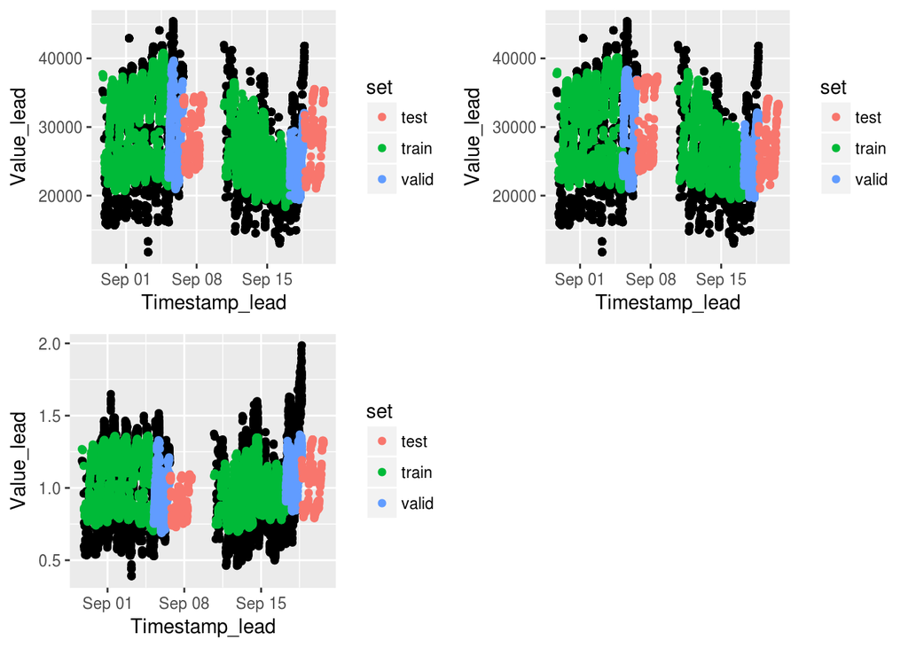

```r
p1 = global %>%
  filter(SiteId == 14) %>%
  filter(ForecastId <= 419) %>%
  mutate(Value_lead = Value_lead * value_last_mean) %>%
  mutate(Value_lead_pred = Value_lead_pred * value_last_mean) %>%
  ggplot(aes(Timestamp_lead, Value_lead)) +
  geom_point() +
  geom_point(aes(Timestamp_lead, Value_lead_pred, color = set))

p2 = global %>%
  filter(SiteId == 14) %>%
  filter(ForecastId <= 419) %>%
  # mutate(Value_lead = Value_lead * value_last_mean) %>%
  # mutate(Value_lead_pred = Value_lead_pred * value_last_mean) %>%
  ggplot(aes(Timestamp_lead, Value_lead)) +
  geom_point() +
  geom_point(aes(Timestamp_lead, Value_lead_pred, color = set))

p3 = global_notNormed %>%
  filter(SiteId == 14) %>%
  filter(ForecastId <= 419) %>%
  ggplot(aes(Timestamp_lead, Value_lead)) +
  geom_point() +
  geom_point(aes(Timestamp_lead, Value_lead_pred, color = set))

multiplot(p1, p2, p3, cols=2)
```

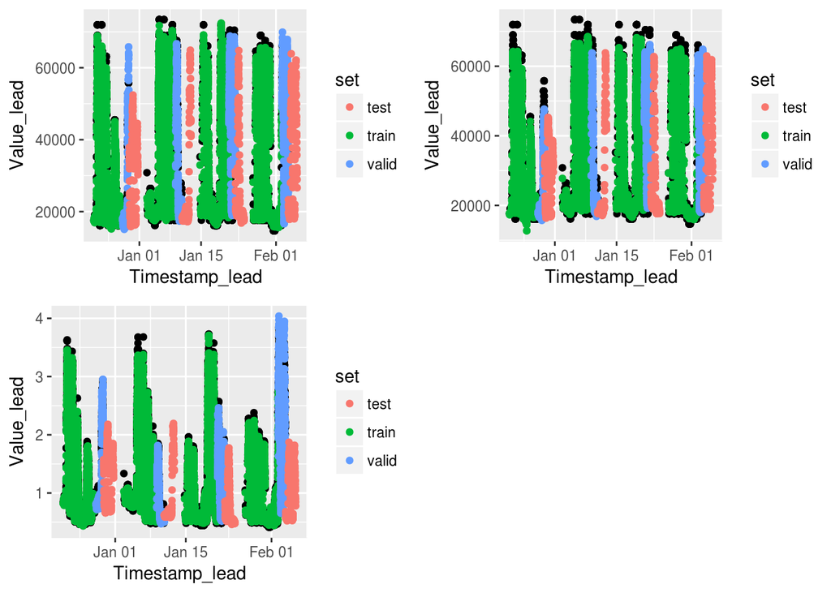

```r
p1 = global %>%
  filter(SiteId == 25) %>%
  filter(ForecastId <= 750) %>%
  mutate(Value_lead = Value_lead * value_last_mean) %>%
  mutate(Value_lead_pred = Value_lead_pred * value_last_mean) %>%
  ggplot(aes(Timestamp_lead, Value_lead)) +
  geom_point() +
  geom_point(aes(Timestamp_lead, Value_lead_pred, color = set))

p2 = global %>%
  filter(SiteId == 25) %>%
  filter(ForecastId <= 750) %>%
  # mutate(Value_lead = Value_lead * value_last_mean) %>%
  # mutate(Value_lead_pred = Value_lead_pred * value_last_mean) %>%
  ggplot(aes(Timestamp_lead, Value_lead)) +
  geom_point() +
  geom_point(aes(Timestamp_lead, Value_lead_pred, color = set))

p3 = global_notNormed %>%
  filter(SiteId == 25) %>%
  filter(ForecastId <= 750) %>%
  ggplot(aes(Timestamp_lead, Value_lead)) +
  geom_point() +
  geom_point(aes(Timestamp_lead, Value_lead_pred, color = set))

multiplot(p1, p2, p3, cols=2)
```

# 7 Eligibility Rules

As already mentioned, your solution cannot be a function that interpolates between past and future data. Submissions that are determined by the judges to violate this constraint will not be eligible for a prize. In general, intellectual honesty should be your guiding principle. Your goal is to build a model that generalizes well enough to forecasting the future, so you must believe you have not overfit the training data.

However i used year, which give a really small boost, as a feature, so why? Does the model extrapolates therefore between past and future data?

In order to understand how the model behave, a dummy (SiteId, ForecastId) were created.

Here is what we are trying to predict. As it can be seen, the dummy series have 500 Value in 2016 and 1000 Values in 2017.

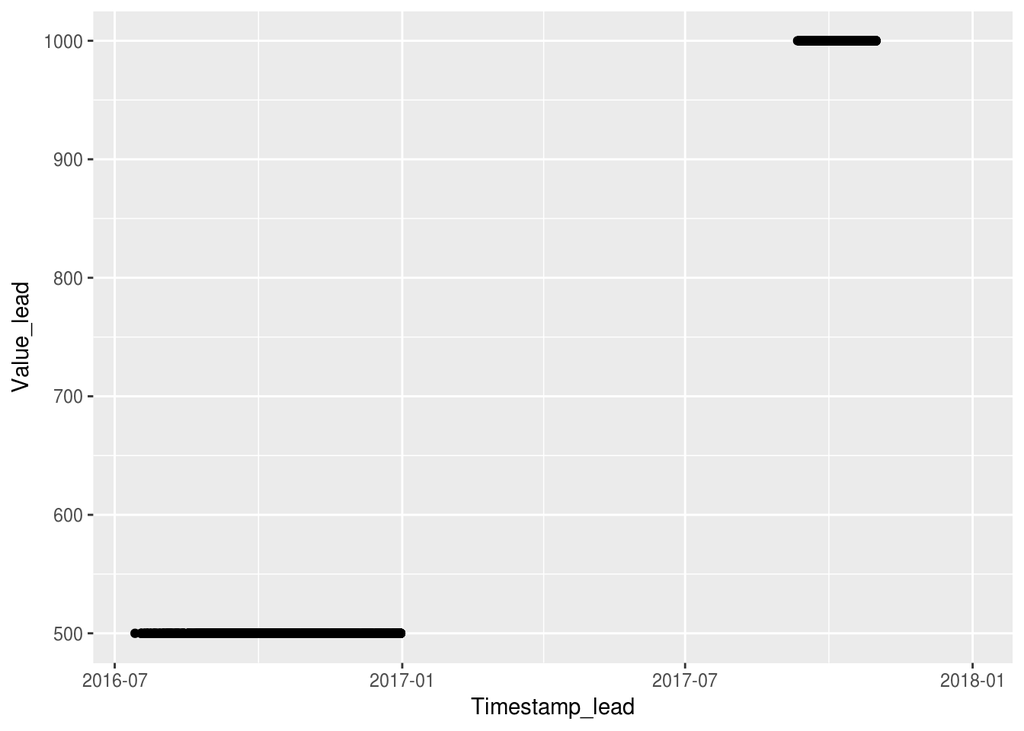

```r
global %>%
  filter(SiteId == 999) %>%
  mutate(Value_lead = Value_lead * value_last_mean) %>%
  mutate(Value_lead_pred = Value_lead_pred * value_last_mean) %>%
  ggplot(aes(Timestamp_lead, Value_lead)) +
  geom_point()
```

Here is what happens when a model is trained without normalization.

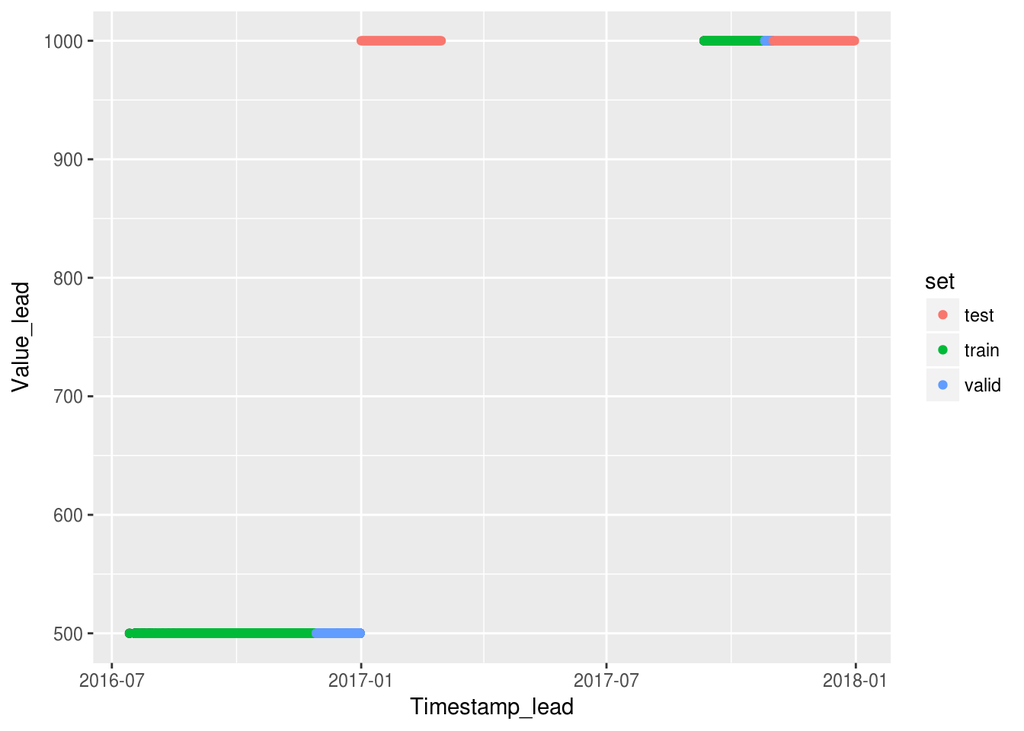

```r
global_notNormed %>%
  filter(SiteId == 999) %>%
  ggplot(aes(Timestamp_lead, Value_lead)) +
  geom_point() +
  geom_point(aes(Timestamp_lead, Value_lead_pred, color = set))
```

The model extrapolates from future values, a forbidden leak is created.

Now, here is what happens when the model is trained with normalization

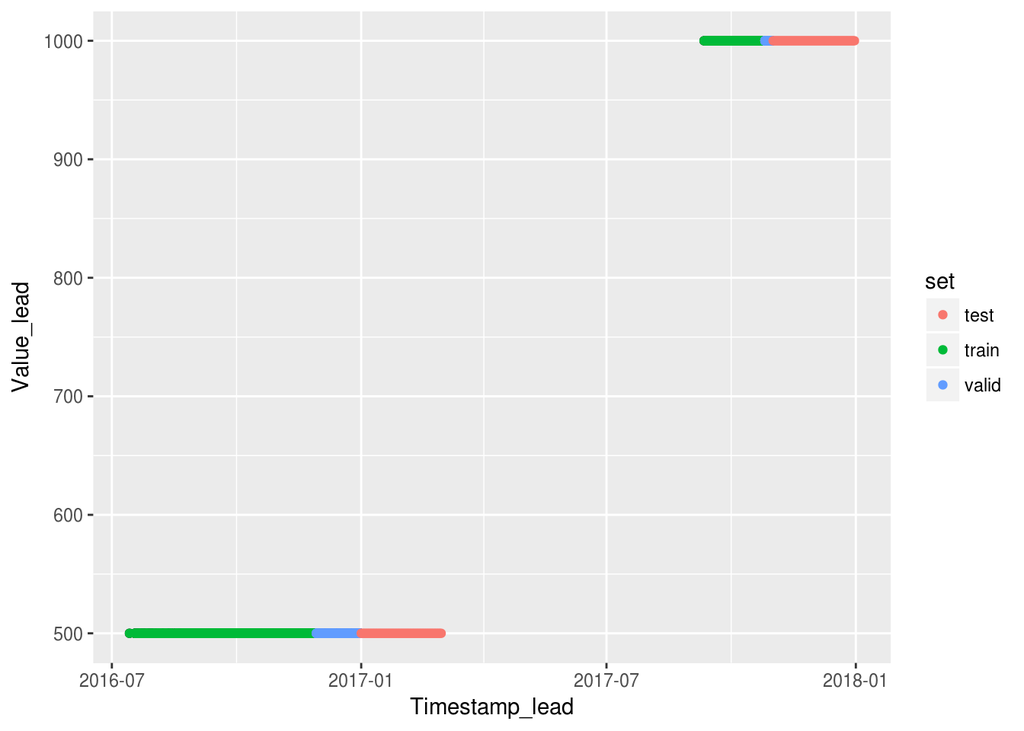

```r
global %>%
  filter(SiteId == 999) %>%
  mutate(Value_lead = Value_lead * value_last_mean) %>%
  mutate(Value_lead_pred = Value_lead_pred * value_last_mean) %>%
  ggplot(aes(Timestamp_lead, Value_lead)) +
  geom_point() +
  geom_point(aes(Timestamp_lead, Value_lead_pred, color = set))
```

The model keep predicting the values from 2016 and not the values from the future in 2017. Why?

Let’s look at what the model is truly trying to predict

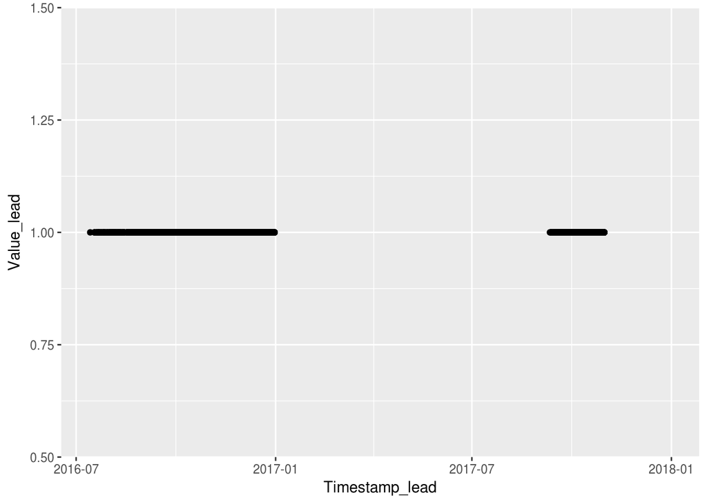

```r
global %>%
  filter(SiteId == 999) %>%
  # mutate(Value_lead = Value_lead * value_last_mean) %>%
  # mutate(Value_lead_pred = Value_lead_pred * value_last_mean) %>%
  ggplot(aes(Timestamp_lead, Value_lead)) +
  geom_point()
```

Since the target is normalized by the mean of past values, the target is constant. As stated above, it is a multiplicative model. This property avoid any extrapolations.

So why year might be a useful feature? We don’t know about the quality of the data, if the informations about opening days were the same during all the training set of the building, if policy about heating and air conditionning changed between 2014 and 2016 for example, changement of ventilation system. If it’s the case, the timeserie the model is trained on have differents behaviour from past values, is not comparable anymore. Even if all the test data were at the end of all SiteId timeseries, this feature would still improve overall model performance.

Obviously this feature could more hidden behind something like the cumsum of Value/Tempreature, mean Value/Temperature of last X months/days. It is also difficult to know when it starts to be tendious (time, day of week, day of month, month (especially when the there is less than one year of data in a Building data), year). I prefer to be honest and I think I showed with a dummy example why using a multiplicative model avoids any extrapoloation problem.

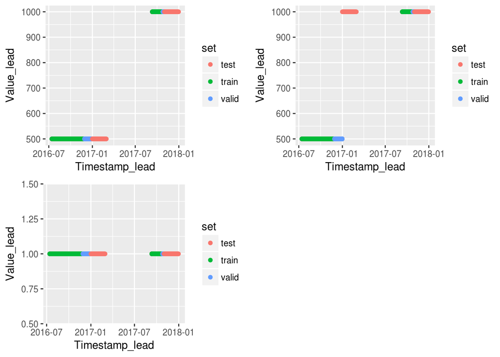

```r
# Dataviz -----------------------------------------------------------------
p1 = global %>%
  filter(SiteId == 999) %>%
  mutate(Value_lead = Value_lead * value_last_mean) %>%
  mutate(Value_lead_pred = Value_lead_pred * value_last_mean) %>%
  ggplot(aes(Timestamp_lead, Value_lead)) +
  geom_point() +
  geom_point(aes(Timestamp_lead, Value_lead_pred, color = set))

p2 = global %>%
  filter(SiteId == 999) %>%
  # mutate(Value_lead = Value_lead * value_last_mean) %>%
  # mutate(Value_lead_pred = Value_lead_pred * value_last_mean) %>%
  ggplot(aes(Timestamp_lead, Value_lead)) +
  geom_point() +
  geom_point(aes(Timestamp_lead, Value_lead_pred, color = set))

p3 = global_notNormed %>%
  filter(SiteId == 999) %>%
  ggplot(aes(Timestamp_lead, Value_lead)) +
  geom_point() +
  geom_point(aes(Timestamp_lead, Value_lead_pred, color = set))

multiplot(p1, p2, p3, cols=2)
```

# 8 Generate submission.csv

If there is no value_mean available (and therefore value_mean is NA), then replace it with the mean of all past value in the SiteId.

```r
# Generate submission.csv -------------------------------------------------
# Correct missing submission
# submission = submission_format %>%
#   select(-Value) %>%
#   left_join(submission %>% select(ForecastId, Timestamp_lead, Value),
#             by = c("ForecastId" = "ForecastId", "Timestamp" = "Timestamp_lead"))
#
# correct_pb_pred = submission %>%
#   filter(is.na(Value)) %>%
#   distinct(SiteId, ForecastId) %>%
#   rowwise() %>% # Not sure it's the best practice see here https://rpubs.com/wch/200398
#   mutate(value_mean_before = get_value_mean_before(v_ForecastId = ForecastId, v_SiteId = SiteId)) %>%
#   ungroup()
#
# submission = submission %>%
#   left_join(correct_pb_pred, by = c("SiteId", "ForecastId")) %>%
#   mutate(Value = if_else(is.na(value_mean_before), Value, value_mean_before)) %>%
#   select(-value_mean_before)
# rm(correct_pb_pred)
#
# sys_time = Sys.time() %>% str_replace_all(" |:", "-")
# file_name = paste0("./output/submission_",
#                    sys_time, ".csv")
#
# submission %>%
#   write_csv(file_name)
#
# system(paste0("zip ", file_name, ".zip ", file_name))
# system(paste0("rm ", file_name))
```